# Previsão de Preços de Imóveis — Resumo para Negócio

# Previsão de Preços de Imóveis

O que este modelo entrega, o quanto ele acerta, e onde eu confiaria menos nele — explicado para quem vai usar o número, não só para quem construiu o modelo.

21,612

vendas usadas para aprender

$66,998

erro típico por imóvel

14.9%

erro típico, em % do preço

Em palavras simples: para um imóvel de valor mediano na região ($450,000), a estimativa do modelo costuma ficar a menos de $66,998 do preço real de venda. Isso é um ponto de partida sólido para negociação e triagem — não um laudo de avaliação final.

## O que mais pesa no preço

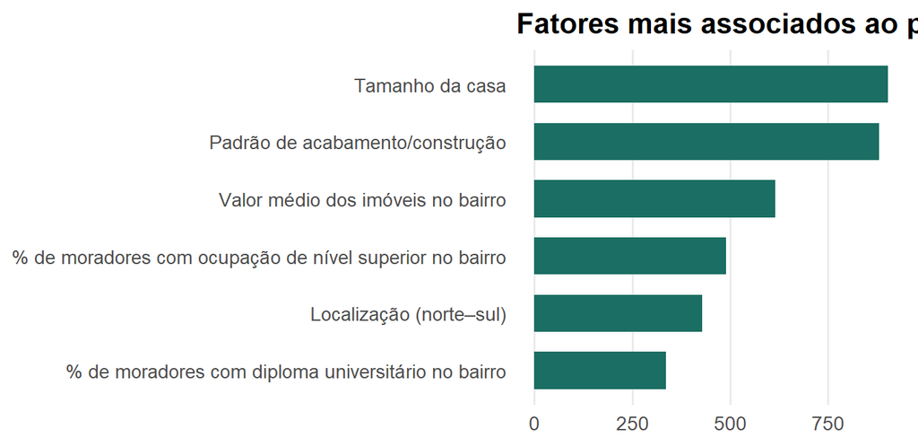

Dois exemplos concretos, direto dos coeficientes do modelo mais simples que testei (regressão linear, mantendo os demais fatores constantes):

**Padrão de acabamento** Cada ponto a mais na escala de padrão construtivo (1 a 13) está associado a cerca de **11.5% a mais** no preço, em média.

**Tamanho da casa** Cada 100 pés² a mais de área construída estão associados a cerca de **1.7% a mais** no preço, em média.

Um ponto que vale destacar: três dos seis fatores mais fortes **não são características do imóvel em si, são do bairro** (valor médio dos imóveis, % de moradores com ocupação de nível superior, % com diploma universitário). Isso quer dizer que o modelo está aprendendo tanto “essa casa é boa” quanto “esse bairro é valorizado” — os dois pesam.

## Por que Random Forest, e não um modelo mais simples

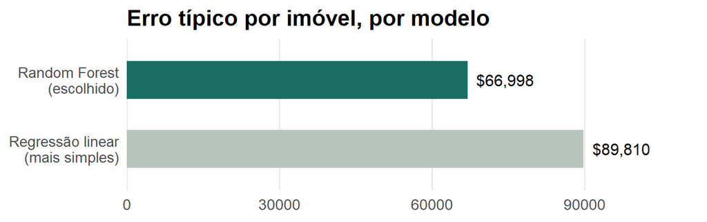

Testei um modelo simples (regressão linear) como referência e um modelo mais flexível (Random Forest). O Random Forest errou, em média, $22,812 a menos por imóvel — a diferença vem principalmente da localização: o efeito da região no preço não é uma linha reta (bairros vizinhos podem ter preços bem diferentes por razões que não seguem um padrão simples), e o modelo mais flexível captura esse tipo de padrão melhor.

## Onde eu confiaria menos na previsão

**Bairros sem histórico de vendas** Quando testei o modelo especificamente em CEPs que ele nunca tinha visto durante o treino, o erro subiu cerca de **16%** em relação ao caso normal — bem mais do que a degradação natural de testar em vendas mais recentes (cerca de 7%). Ou seja: a maior fraqueza do modelo não é “ficar desatualizado com o tempo”, é **avaliar um bairro novo ou raramente vendido**. Nesses casos, recomendo tratar a previsão como um número inicial a ser confirmado por uma avaliação humana, não como resposta final.

**Imóveis de altíssimo padrão** Nos testes, o modelo tende a **subestimar** o preço dos imóveis mais caros da base (mansões, propriedades excepcionais) — uma limitação conhecida desse tipo de modelo, que estima por meio de uma média entre muitas árvores de decisão e por isso tem dificuldade em alcançar os valores mais extremos. Para esse segmento específico, o número do modelo deve ser tratado como piso, não como estimativa central.

## Como eu recomendaria usar isso no dia a dia

- Como **ponto de partida de negociação** ou **triagem em massa** (ex.: sinalizar imóveis com preço pedido muito fora da estimativa do modelo, para revisão prioritária).
- **Não** como laudo de avaliação final — nenhum modelo estatístico substitui uma vistoria para casos de alto valor ou de bairro pouco representado no histórico.
- Combinado com a flag de confiança descrita na estratégia de deploy: quando o imóvel estiver num CEP fora do treino, o número deve vir acompanhado de um aviso, não apresentado com a mesma confiança de um bairro bem coberto.